# TP3 - Exercice 3 : Une application forestière

Tracy ANDRE

8th May, 2023

**Note pour le notebook :**

Executing this chunk *Ctrl+Shift+Enter*

Add a new chunk *Ctrl+Alt+I*.

Preview *Ctrl+Shift+K*

#### **Q1 - Importation des données**

```r
setwd("C:/Users/andre/OneDrive/Documents/S6/Stats/TP3_Donnees")
eucal <- read.table("eucalyptus.txt",header=T)
attach(eucal)
head(eucal)
```

|  | ht | circ | bloc | clone |
| --- | --- | --- | --- | --- |
| 1 | 18.25 | 36 | 1 | L2-123 |
| 2 | 19.75 | 42 | 1 | L2-123 |
| 3 | 16.50 | 33 | 1 | L2-123 |
| 4 | 18.25 | 39 | 1 | L2-123 |
| 5 | 19.50 | 43 | 1 | L2-123 |
| 6 | 16.25 | 34 | 1 | L2-123 |

```r
summary(eucal)
```

```
       ht             circ            bloc          clone
 Min.   :11.25   Min.   :26.00   Min.   :1.000   Length:1429
 1st Qu.:19.75   1st Qu.:42.00   1st Qu.:1.000   Class :character
 Median :21.75   Median :48.00   Median :2.000   Mode  :character
 Mean   :21.21   Mean   :47.35   Mean   :1.852
 3rd Qu.:23.00   3rd Qu.:54.00   3rd Qu.:2.000
 Max.   :27.75   Max.   :77.00   Max.   :3.000
```

#### **Q2 - Nuage de points**

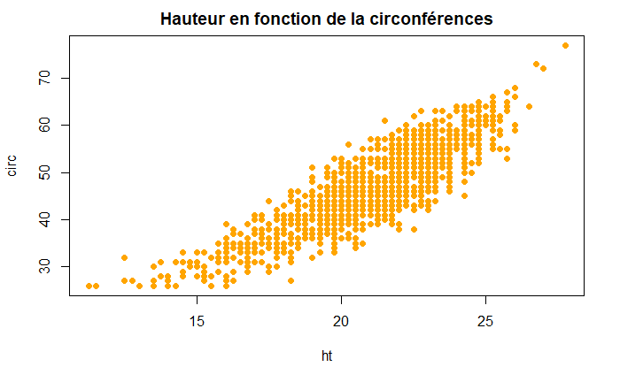

```r
plot(ht, circ, pch = 19, col = "orange", title("Hauteur en fonction de la circonférences"))
```

#### **Q3 - Modèle linéaire simple**

$$\forall i = 1,..., n \quad Y_i = \beta_0 + \beta_1x_i + \epsilon_i$$

avec comme hypothèses :

- erreurs résiduelles sont indépendantes et de même loi $\mathcal{N}(0,\sigma^2)$
- que la variance des erreurs est constante
- hypothèse de linéarité suppose que la relation entre X et Y est linéaire

#### **Q4 - Superposition nuage de points et droite de régression**

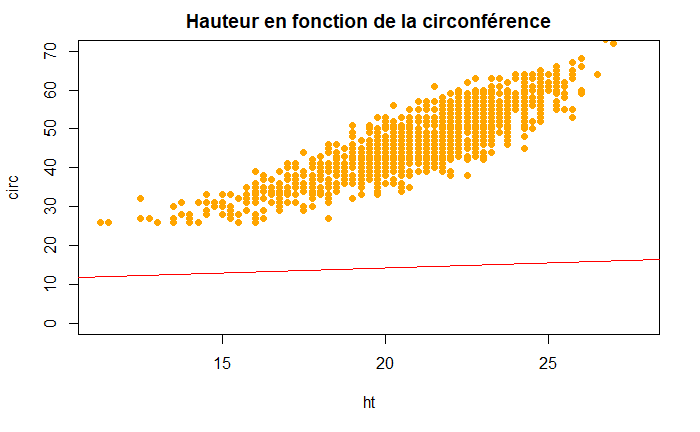

```r
model1 <- lm(ht ~ circ, data = eucal)
plot(ht, circ, pch = 19, col = "orange", title("Hauteur en fonction de la circonférence"), ylim = c(0,70))
abline(model1, col="red")
```

#### **Q4(bis) - Graphe des résidus**

```r
plot(model1$fitted.values, model1$residuals, col = "red", pch = 19, xlab = "^y", ylab = "Residuals")
resume1 <- summary(model1)
abline(h=0)
```

[figure not shown]

```r
abline(h=-2*resume1$sigma,lty=2, col = "blue")
abline(h=2*resume1$sigma, lty=2, col = "orange")
```

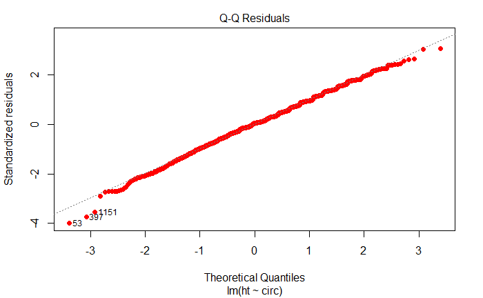

```r
plot(model1, col = "red", pch = 19, which = 2)
```

On peut voir que les hypothèses semblent bien être vérifiée, malgré une petite agglomération des points.

#### **Q5 - Modèle de régression multiple**

*(a) Modèle sous forme matricielle*

$$Ht = Circ \times \beta + \epsilon$$
avec :
$$Ht = \begin{pmatrix} Ht_1 \\ Ht_2 \\ ... \\ Ht_n \end{pmatrix} ,
Circ_{n \times 3} = \begin{pmatrix} 1&circ_{1,1}&\sqrt{circ_{1,2}} \\ .&.&. \\ .&.&. \\ 1&circ_{n,1}&\sqrt{circ_{n,2}} \end{pmatrix},
\beta = \begin{pmatrix} \beta_0 \\ \beta_1 \\ \beta_2 \end{pmatrix},
E_{n \times 1} = \begin{pmatrix} \epsilon_1 \\ \epsilon_2 \\ . \\ . \\ \epsilon_n \end{pmatrix}$$

*(b) Estimation des paramètres*

$$\hat{\beta} = (X'X) \times X' \times H_t$$

```r
n <- length(ht)
X <- matrix(c(rep(1,n), circ, sqrt(circ)), ncol=3)
beta_chapo <- solve(t(X) %*% X) %*% t(X) %*% ht
beta_chapo
```

```
            [,1]
[1,] -24.3520033
[2,]  -0.4829455
[3,]   9.9868881
```

*(c) Variance résiduelle*

$$E = Y - \hat{Y}$$
$$\hat{\sigma} = \frac{E'E}{n -p - 1}$$

```r
residus <- ht - X %*% beta_chapo
sigma_chapo <- t(residus) %*% residus / (n-length(beta_chapo))
sigma_chapo
```

```
         [,1]
[1,] 1.290783
```

*(d) Estimation de l’écart-type des beta chapo*

pas compris celle ci : essayer de le faire à la mano

```r
s_beta <- sqrt(sigma_chapo * diag(solve(t(X)%*% X)))
```

```
Recycling array of length 1 in array-vector arithmetic is deprecated.
  Use c() or as.vector() instead.
```

```r
s_beta
```

```
[1] 2.61444160 0.05793473 0.78032526
```

*(e) La circonférence d’un arbre a une influence sur sa hauteur ?*

Hypothèses du test de Student :

$$H_0 : \left\{ \beta_j = 0 \right\}$$

La statistique de test et sa loi :

$$t = \frac{\hat{\beta_j}}{\hat{\sigma_{\beta_j}}}$$